# Math 421 - Midterm

## Instruction

The midterm has two components: the Rmarkdown notebook (html) and the presentation. We will do the presentation in class. Post both the notebook and the presentation on your Github page.

**The notebook:** The notebook should be created using `rmarkdown` or Quarto (like other assignments). The notebook should have a title.

**The Presentation:** Present your results in 5-10 minutes. To make the presentation using Rmarkdown, do the follows:

```
- In Rstudio -> File -> New File -> R markdown

- In the left panel, click to Presentation -> Click OK

- Now you have an Rmarkdown that can be knitted to be a html presentation
```

- You can also use the Rmd templates of the class slides.
- You can also use Quarto to create the presentation: *In Rstudio -> File -> New File -> Quarto Presentation…*
- You do not need to rerun all the codes for the presentation. For example, to show the model comparison, you just need to show the image of the model comparison instead of running all the models again.
- To inset an image in a slide, use `![](image.png)`
- To scale images, you can use `![](image.png){width="60%"}` or follow these below instructions.
  - https://bookdown.org/yihui/rmarkdown-cookbook/figure-size.html
  - http://zevross.com/blog/2017/06/19/tips-and-tricks-for-working-with-images-and-figures-in-r-markdown-documents/
- To turn off message and warning of a code cell, use: `{r, message=FALSE, warning=FALSE}` for the cell.

**What to present**:

- Present Part 2 - Visualization
- Present Question Question 4, 5 and 6 in Part 3.
- Present any errors/challenges you run into and how you fix/overcome them.

**Data:**

The data for the mid-term project is the Rhode Island Department of Health Hospital Discharge Data. Each row of the data presents a patient.

Link: https://drive.google.com/open?id=15QNBf6YYKocK2nNIfpKDer58kQnCPNZJ

**Notice**

- Since this is a large dataset, you could try to run the codes on the smaller dataset, which is a portion of the original dataset before running the codes on the original data. To create a random subset of the data you could use

```r
# find the number of rows of the data
n = nrow(df)

# subset 1000 rows of the data
df1 = df[sample(1:n, 1000), ]
```

## I. Data Wranggling

1. Download the data file `hdd0318cy.sas7bdat`.

   ```r
   library(haven)
   library(dplyr)
   library(tidyr)
   library(stringr)
   library(readr)

   df <- read_sas("C:/Users/student/Downloads/hdd0318cy (1).sas7bdat")

   n = nrow(df)


   df1 = df[sample(1:n, 1000), ]

   vars <- c(
     "yod","payfix","pay_ub92","age","sex","raceethn","provider","moa",
     "yoa","mod","admtype","asource","preopday","los","service","icu","ccu",
     "dispub92","payer","drg","trandb","randbg","randbs","orr","anes","seq",
     "lab","dtest","ther","blood","phar","other","patcon","bwght","total","tot",
     "ecodub92","b_wt","pt_state","diag_adm","ancilar","campus","er_fee","er_chrg",
     "er_mode","obs_chrg","obs_hour","psycchrg","nicu_day"
   )

   df18 <- df %>%
     filter(yod == 18) %>%
     select(any_of(vars))

   write_csv(df18, "midterm_2018_selected.csv")
   ```

2. Use `read_sas` in library `haven` to read the data.
3. Filter the data to have only patients of the year 2018 (`yod=18`)
4. Select to work with only following variables:

```r
                      "yod", "payfix","pay_ub92","age",
                      "sex","raceethn","provider","moa",
                      "yoa","mod","admtype", "asource" ,
                      "preopday" ,"los", "service" , "icu","ccu",
                      "dispub92", "payer"  ,"drg","trandb",
                      "randbg","randbs","orr", "anes","seq",
                      "lab","dtest", "ther","blood","phar",
                      "other","patcon","bwght","total","tot" ,
                      "ecodub92","b_wt","pt_state","diag_adm","ancilar" ,
                      "campus","er_fee","er_chrg","er_mode","obs_chrg",
                      "obs_hour","psycchrg","nicu_day"
```

*Notice*: You may want to save the current data to your computer for easy access later. To save the data file use `write_csv(df, 'midterm.csv')`, for example. Also notice that, empty values in the data before writing to csv may turn to NAs later when you re-read the file.

5. What are variables that have missing values?

   ```r
   is_missing <- function(x) {
     if (is.character(x)) is.na(x) | str_trim(x) == "" else is.na(x)
   }

   missing_summary <- tibble(
     variable = names(df18),
     missing_n = sapply(df18, function(x) sum(is_missing(x))),
     missing_pct = sapply(df18, function(x) mean(is_missing(x)))
   ) %>%
     arrange(desc(missing_n))

   missing_summary
   ```

   ```
   ## # A tibble: 49 × 3
   ##    variable missing_n missing_pct
   ##    <chr>        <int>       <dbl>
   ##  1 payfix      131478   1
   ##  2 bwght       131478   1
   ##  3 nicu_day    124090   0.944
   ##  4 ecodub92    104339   0.794
   ##  5 obs_hour     77343   0.588
   ##  6 preopday     60486   0.460
   ##  7 er_mode      12158   0.0925
   ##  8 raceethn      3950   0.0300
   ##  9 diag_adm        50   0.000380
   ## 10 asource          6   0.0000456
   ## # ℹ 39 more rows
   ```

6. Remove all variables with missing values.

   ```r
   keep_vars <- names(df18)[sapply(df18, function(x) sum(is_missing(x)) == 0)]
   df18_nomissvars <- df18 %>% select(all_of(keep_vars))

   df18_nomissvars
   ```

   ```
   ## # A tibble: 131,478 × 37
   ##      yod pay_ub92   age sex   provider   moa   yoa   mod   los service icu
   ##    <dbl>    <dbl> <dbl> <chr> <chr>    <dbl> <dbl> <dbl> <dbl> <chr>   <chr>
   ##  1    18        9     0 1     7214         1    18     1     2 00      000000
   ##  2    18        2    76 2     7214         1    18     1     1 00      000000
   ##  3    18        6    50 2     7214        12    17     1     3 00      000000
   ##  4    18        4     0 1     7214         1    18     1     4 00      000000
   ##  5    18       13     0 1     7214        12    17     1    35 00      000000
   ##  6    18        4     0 2     7214        12    17     1    17 00      000000
   ##  7    18        4     0 2     7214         1    18     1     2 00      000000
   ##  8    18       13     0 2     7214         1    18     1     3 00      000000
   ##  9    18        1    70 2     7214         1    18     1     2 00      000000
   ## 10    18        9    25 2     7214        12    17     1    12 00      000000
   ## # ℹ 131,468 more rows
   ## # ℹ 26 more variables: ccu <chr>, dispub92 <chr>, payer <chr>, drg <dbl>,
   ## #   trandb <chr>, randbg <chr>, randbs <chr>, orr <chr>, anes <chr>, seq <chr>,
   ## #   lab <chr>, dtest <chr>, ther <chr>, blood <chr>, phar <chr>, other <chr>,
   ## #   patcon <chr>, total <chr>, tot <dbl>, b_wt <chr>, ancilar <chr>,
   ## #   campus <chr>, er_fee <chr>, er_chrg <chr>, obs_chrg <chr>, psycchrg <chr>
   ```

7. Refer to the data description in the file `HDD2015-18cy6-20-19.docx`, which variable recording the month of admission?, which variable recording the month of discharge?

   ```r
   c(month_admission = "moa", month_discharge = "mod")
   ```

   ```
   ## month_admission month_discharge
   ##           "moa"           "mod"
   ```

8. Which month admitted the most number of patients? Which month admitted the most number of male patients?

   ```r
   most_admit_month <- df18_nomissvars %>%
     count(moa, name = "n") %>%
     arrange(desc(n))

   most_admit_month
   ```

   ```
   ## # A tibble: 12 × 2
   ##      moa     n
   ##    <dbl> <int>
   ##  1    10 11408
   ##  2     5 11404
   ##  3     1 11309
   ##  4     8 11199
   ##  5     4 11174
   ##  6     3 11073
   ##  7     7 10962
   ##  8    12 10698
   ##  9     6 10690
   ## 10     9 10666
   ## 11    11 10636
   ## 12     2 10259
   ```

   ```r
   most_admit_month_male <- df18_nomissvars %>%
     filter(sex %in% c("M","Male","1")) %>%
     count(moa, name = "n") %>%
     arrange(desc(n))

   most_admit_month_male
   ```

   ```
   ## # A tibble: 12 × 2
   ##      moa     n
   ##    <dbl> <int>
   ##  1    10  5164
   ##  2     5  5066
   ##  3     8  5028
   ##  4     4  4989
   ##  5     3  4978
   ##  6     1  4970
   ##  7     7  4910
   ##  8    12  4855
   ##  9     6  4810
   ## 10    11  4800
   ## 11     9  4683
   ## 12     2  4546
   ```

9. Which month has the most number of teenage female patients?

   ```r
   teen_female_by_month <- df18_nomissvars %>%
     filter(age >= 13, age <= 19, sex %in% c("F","Female","2")) %>%
     count(moa, name = "n") %>%
     arrange(desc(n))

   teen_female_by_month
   ```

   ```
   ## # A tibble: 12 × 2
   ##      moa     n
   ##    <dbl> <int>
   ##  1     3   226
   ##  2     5   220
   ##  3    10   212
   ##  4    12   208
   ##  5     1   207
   ##  6     9   196
   ##  7     4   187
   ##  8    11   177
   ##  9     2   172
   ## 10     8   172
   ## 11     7   171
   ## 12     6   169
   ```

10. Which provider has the most number of female patients in October?

    ```r
    top_provider_female_oct <- df18_nomissvars %>%
      filter(moa == 10, sex %in% c("F","Female","2")) %>%
      count(provider, name = "n") %>%
      arrange(desc(n))

    top_provider_female_oct
    ```

    ```
    ## # A tibble: 12 × 2
    ##    provider     n
    ##    <chr>    <int>
    ##  1 7205      1517
    ##  2 7214      1224
    ##  3 7204       872
    ##  4 7210       699
    ##  5 7209       351
    ##  6 7206       333
    ##  7 7213       317
    ##  8 7201       294
    ##  9 7216       256
    ## 10 7202       212
    ## 11 7211       122
    ## 12 7215        46
    ```

11. Are female patients older than male patients, on average?

    ```r
    avg_age_by_sex <- df18_nomissvars %>%
      filter(sex %in% c("M","Male","1","F","Female","2")) %>%
      group_by(sex) %>%
      summarize(
        n = n(),
        avg_age = mean(as.numeric(age), na.rm = TRUE),
        median_age = median(as.numeric(age), na.rm = TRUE),
        .groups = "drop"
      )

    avg_age_by_sex
    ```

    ```
    ## # A tibble: 2 × 4
    ##   sex       n avg_age median_age
    ##   <chr> <int>   <dbl>      <dbl>
    ## 1 1     58799    51.5         57
    ## 2 2     72675    50.9         54
    ```

12. Calculate the average age of patients by months. Which month has the oldest patients on average age?

    ```r
    avg_age_by_month <- df18_nomissvars %>%
      group_by(moa) %>%
      summarize(
        n = n(),
        avg_age = mean(as.numeric(age), na.rm = TRUE),
        .groups = "drop"
      ) %>%
      arrange(desc(avg_age))

    avg_age_by_month
    ```

    ```
    ## # A tibble: 12 × 3
    ##      moa     n avg_age
    ##    <dbl> <int>   <dbl>
    ##  1     1 11309    51.8
    ##  2     6 10690    51.5
    ##  3    12 10698    51.5
    ##  4     4 11174    51.4
    ##  5     7 10962    51.3
    ##  6     2 10259    51.2
    ##  7     3 11073    51.1
    ##  8    11 10636    51.0
    ##  9     8 11199    50.9
    ## 10    10 11408    50.8
    ## 11     5 11404    50.6
    ## 12     9 10666    50.6
    ```

13. What is the name of the provider that has the highest total charge?

    ```r
    provider_highest_total_charge <- df18_nomissvars %>%
      group_by(provider) %>%
      summarize(
        total_charge = sum(as.numeric(tot), na.rm = TRUE),
        .groups = "drop"
      ) %>%
      arrange(desc(total_charge))

    provider_highest_total_charge
    ```

    ```
    ## # A tibble: 12 × 2
    ##    provider total_charge
    ##    <chr>           <dbl>
    ##  1 7205       1788373499
    ##  2 7204        678940049
    ##  3 7214        428480981
    ##  4 7210        427464111
    ##  5 7213        240776070
    ##  6 7206        212906243
    ##  7 7202        187925007
    ##  8 7209        163943679
    ##  9 7201        126539717
    ## 10 7216        114603878
    ## 11 7215         77010051
    ## 12 7211         64990985
    ```

14. What is the name of the provider that has the least total charge for teenage male on average?

    ```r
    provider_lowest_avg_charge_teen_male <- df18_nomissvars %>%
      filter(age >= 13, age <= 19, sex %in% c("M","Male","1")) %>%
      group_by(provider) %>%
      summarize(
        n = n(),
        avg_charge = mean(as.numeric(tot), na.rm = TRUE),
        .groups = "drop"
      ) %>%
      filter(n > 0) %>%
      arrange(avg_charge)

    provider_lowest_avg_charge_teen_male
    ```

    ```
    ## # A tibble: 12 × 3
    ##    provider     n avg_charge
    ##    <chr>    <int>      <dbl>
    ##  1 7206         9     10360.
    ##  2 7201        38     14434.
    ##  3 7210        38     18586.
    ##  4 7211        10     19742.
    ##  5 7213        21     22618.
    ##  6 7216       101     24060.
    ##  7 7204        32     24989.
    ##  8 7209         9     26573.
    ##  9 7214         1     28950
    ## 10 7202        22     29389.
    ## 11 7205       804     40215.
    ## 12 7215       300    100440.
    ```

15. Create a season (Spring, Summer, Fall, Winter) variable. Calculate the length of stays by season. Which season has the longest length of stays on average?

    ```r
    df18_season <- df18_nomissvars %>%
      mutate(
        season = case_when(
          moa %in% c(3,4,5) ~ "Spring",
          moa %in% c(6,7,8) ~ "Summer",
          moa %in% c(9,10,11) ~ "Fall",
          moa %in% c(12,1,2) ~ "Winter",
          TRUE ~ NA_character_
        )
      )

    los_by_season <- df18_season %>%
      filter(!is.na(season)) %>%
      group_by(season) %>%
      summarize(
        n = n(),
        avg_los = mean(as.numeric(los), na.rm = TRUE),
        .groups = "drop"
      ) %>%
      arrange(desc(avg_los))

    los_by_season
    ```

    ```
    ## # A tibble: 4 × 3
    ##   season     n avg_los
    ##   <chr>  <int>   <dbl>
    ## 1 Summer 32851    4.96
    ## 2 Fall   32710    4.96
    ## 3 Winter 32266    4.93
    ## 4 Spring 33651    4.84
    ```

16. On average, how much a 20 year-old male get charged for staying 1 day in the Fall season?

    ```r
    avg_charge_20_male_1day_fall <- df18_season %>%
      filter(age == 20, sex %in% c("M","Male","1"), season == "Fall", los == 1) %>%
      summarize(
        n = n(),
        avg_charge = mean(as.numeric(tot), na.rm = TRUE)
      )

    avg_charge_20_male_1day_fall
    ```

    ```
    ## # A tibble: 1 × 2
    ##       n avg_charge
    ##   <int>      <dbl>
    ## 1     6      16511
    ```

17. Write a paragraph to summarize the section and give your comments on the results. You could do some other calculations to support your points.

## II. Data Visualization

Continue with the data from part I.

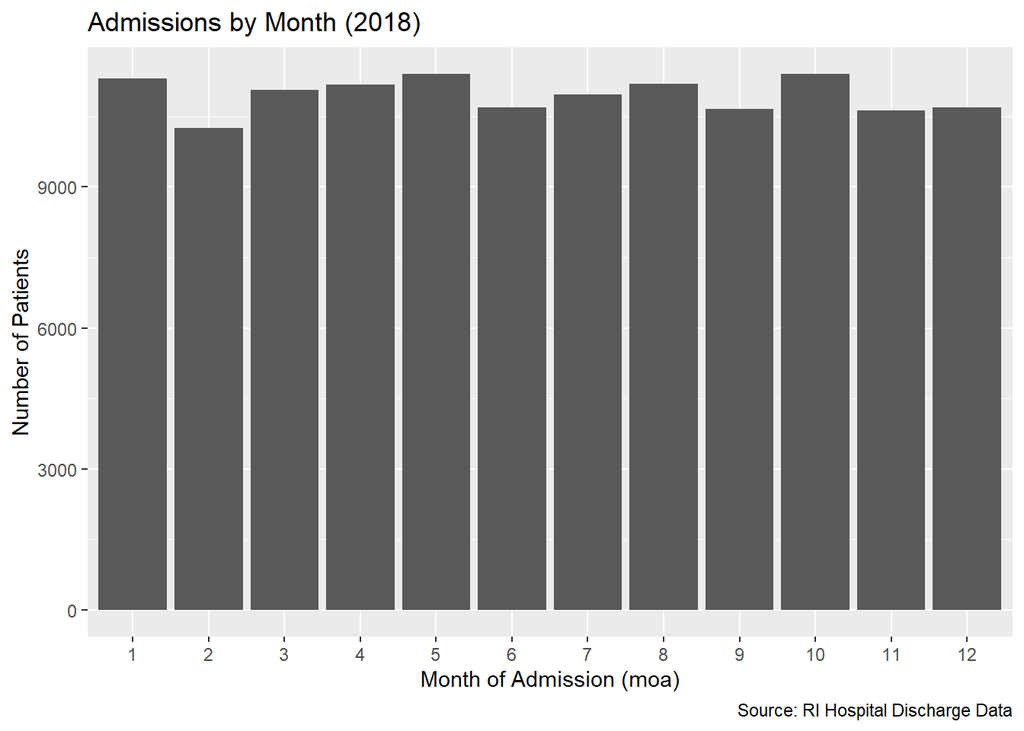

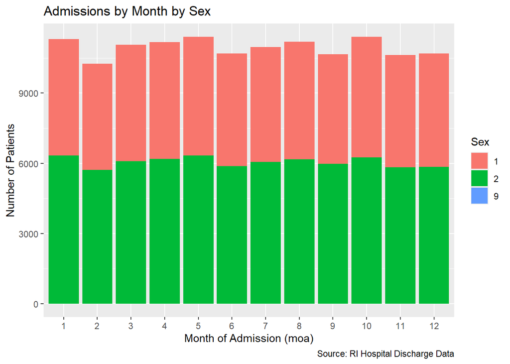

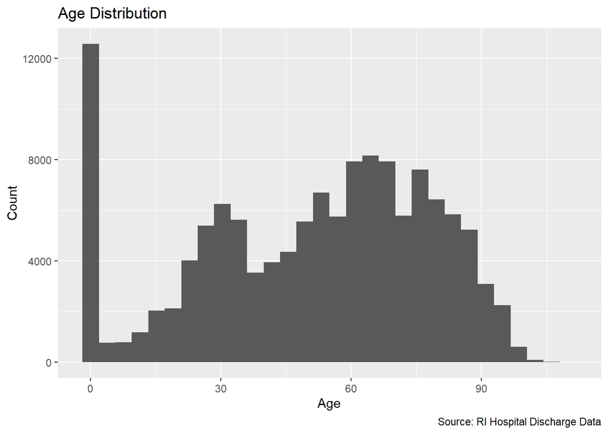

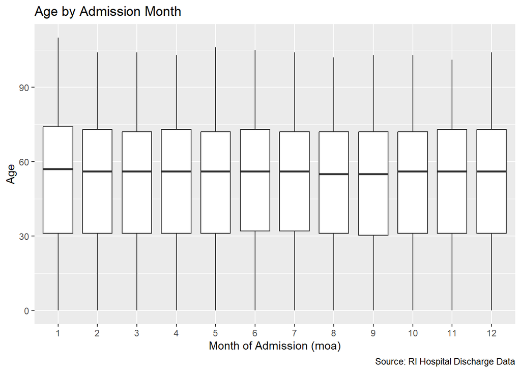

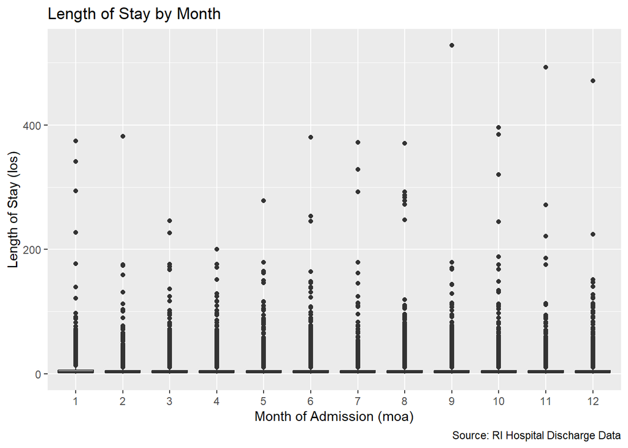

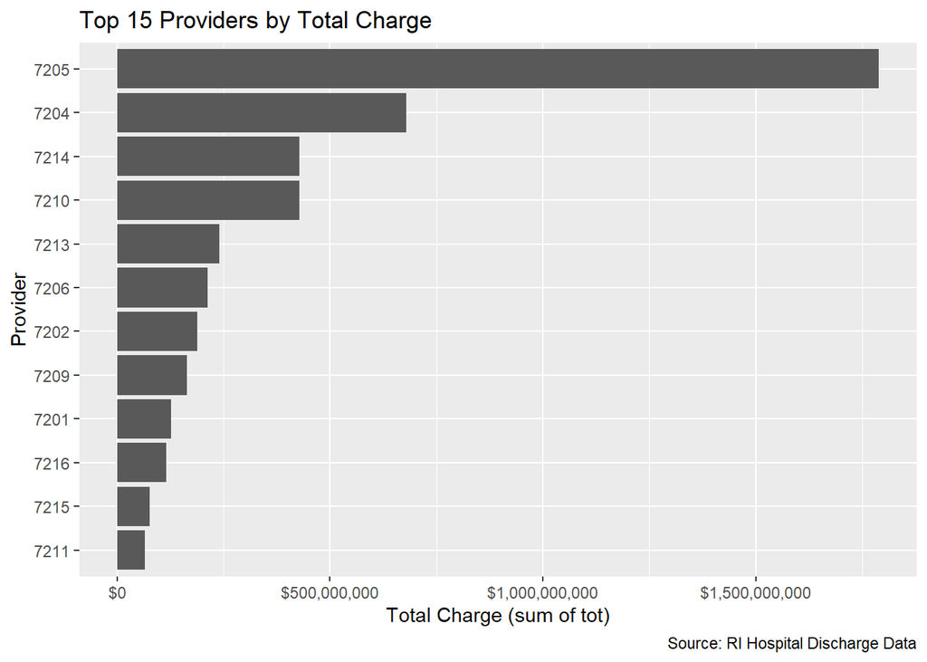

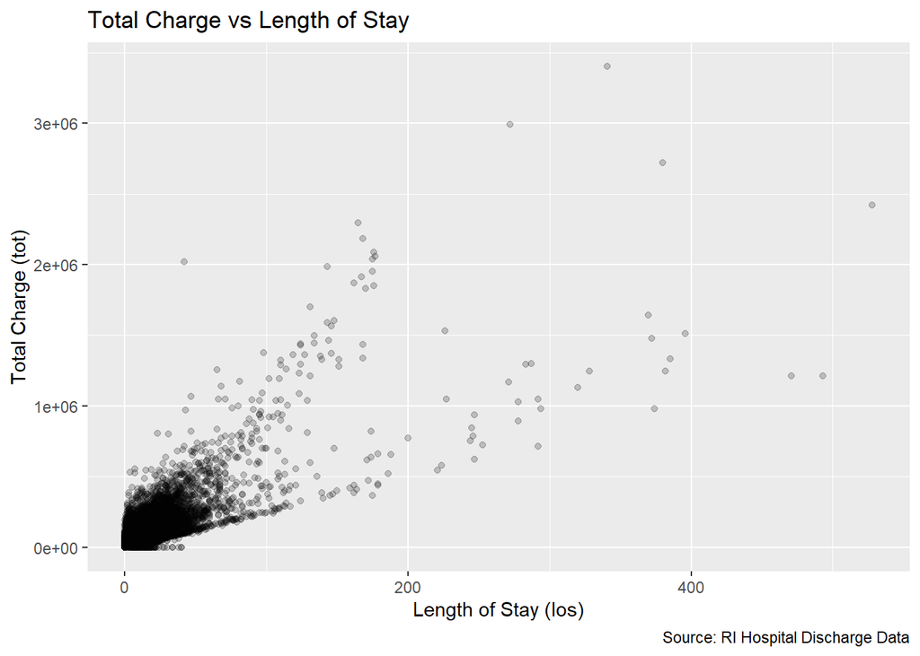

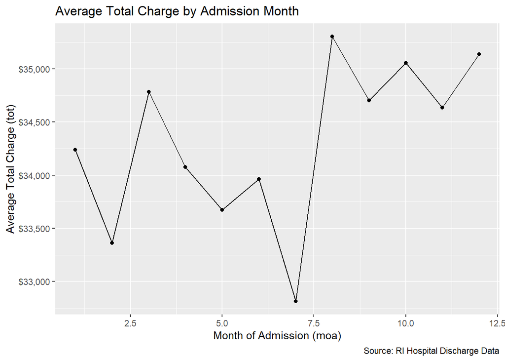

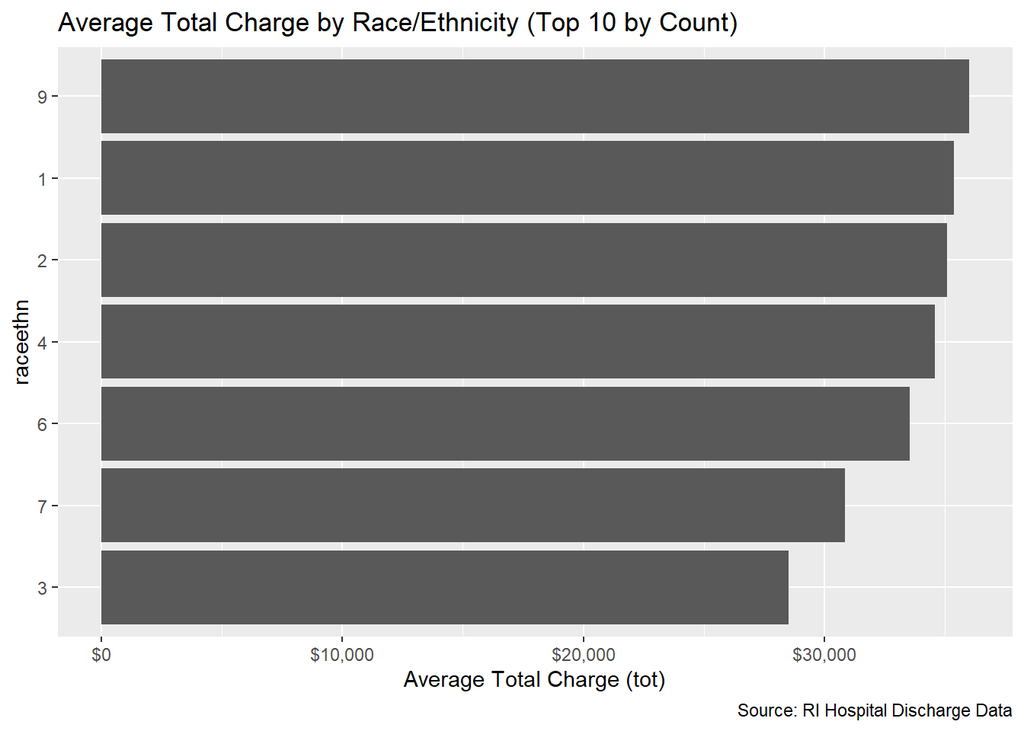

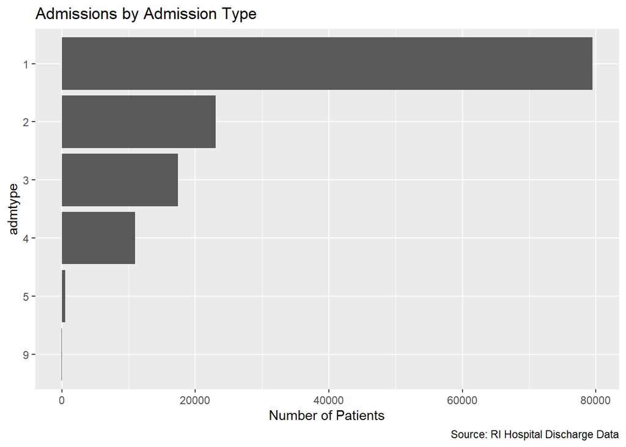

   ```r
   library(dplyr)
   library(stringr)
   library(ggplot2)
   library(scales)
   library(gganimate)

   df_viz <- df18 %>%
     filter(yod == 18) %>%
     select(any_of(c("moa","sex","age","los","provider","tot","raceethn","admtype"))) %>%
     mutate(
       moa = as.integer(moa),
       sex = factor(sex),
       age = as.numeric(age),
       los = as.numeric(los),
       tot = as.numeric(tot),
       provider = factor(provider)
     )

   p1 <- ggplot(df_viz, aes(x = factor(moa))) +
     geom_bar() +
     labs(title = "Admissions by Month (2018)", x = "Month of Admission (moa)", y = "Number of Patients",
          caption = "Source: RI Hospital Discharge Data")

   p2 <- ggplot(df_viz, aes(x = factor(moa), fill = sex)) +
     geom_bar() +
     labs(title = "Admissions by Month by Sex", x = "Month of Admission (moa)", y = "Number of Patients", fill = "Sex",
          caption = "Source: RI Hospital Discharge Data")

   p3 <- ggplot(df_viz, aes(x = age)) +
     geom_histogram(bins = 30) +
     labs(title = "Age Distribution", x = "Age", y = "Count",
          caption = "Source: RI Hospital Discharge Data")

   p4 <- ggplot(df_viz, aes(x = factor(moa), y = age)) +
     geom_boxplot() +
     labs(title = "Age by Admission Month", x = "Month of Admission (moa)", y = "Age",
          caption = "Source: RI Hospital Discharge Data")

   p5 <- ggplot(df_viz, aes(x = factor(moa), y = los)) +
     geom_boxplot() +
     labs(title = "Length of Stay by Month", x = "Month of Admission (moa)", y = "Length of Stay (los)",
          caption = "Source: RI Hospital Discharge Data")

   p6 <- df_viz %>%
     group_by(provider) %>%
     summarize(total_charge = sum(tot, na.rm = TRUE), .groups = "drop") %>%
     slice_max(total_charge, n = 15, with_ties = FALSE) %>%
     ggplot(aes(x = reorder(provider, total_charge), y = total_charge)) +
     geom_col() +
     coord_flip() +
     scale_y_continuous(labels = dollar) +
     labs(title = "Top 15 Providers by Total Charge", x = "Provider", y = "Total Charge (sum of tot)",
          caption = "Source: RI Hospital Discharge Data")

   p7 <- ggplot(df_viz, aes(x = los, y = tot)) +
     geom_point(alpha = 0.2) +
     labs(title = "Total Charge vs Length of Stay", x = "Length of Stay (los)", y = "Total Charge (tot)",
          caption = "Source: RI Hospital Discharge Data")

   p8 <- df_viz %>%
     group_by(moa) %>%
     summarize(avg_tot = mean(tot, na.rm = TRUE), .groups = "drop") %>%
     ggplot(aes(x = moa, y = avg_tot)) +
     geom_line() +
     geom_point() +
     scale_y_continuous(labels = dollar) +
     labs(title = "Average Total Charge by Admission Month", x = "Month of Admission (moa)", y = "Average Total Charge (tot)",
          caption = "Source: RI Hospital Discharge Data")

   if ("raceethn" %in% names(df_viz)) {
     p9 <- df_viz %>%
       filter(!is.na(raceethn), str_trim(as.character(raceethn)) != "") %>%
       group_by(raceethn) %>%
       summarize(avg_tot = mean(tot, na.rm = TRUE), n = n(), .groups = "drop") %>%
       slice_max(n, n = 10, with_ties = FALSE) %>%
       ggplot(aes(x = reorder(raceethn, avg_tot), y = avg_tot)) +
       geom_col() +
       coord_flip() +
       scale_y_continuous(labels = dollar) +
       labs(title = "Average Total Charge by Race/Ethnicity (Top 10 by Count)", x = "raceethn", y = "Average Total Charge (tot)",
            caption = "Source: RI Hospital Discharge Data")
   } else {
     p9 <- ggplot() + labs(title = "raceethn not available in this dataset")
   }

   if ("admtype" %in% names(df_viz)) {
     p10 <- df_viz %>%
       filter(!is.na(admtype), str_trim(as.character(admtype)) != "") %>%
       count(admtype, name = "n") %>%
       ggplot(aes(x = reorder(admtype, n), y = n)) +
       geom_col() +
       coord_flip() +
       labs(title = "Admissions by Admission Type", x = "admtype", y = "Number of Patients",
            caption = "Source: RI Hospital Discharge Data")
   } else {
     p10 <- ggplot() + labs(title = "admtype not available in this dataset")
   }

   plots <- list(p1,p2,p3,p4,p5,p6,p7,p8,p9,p10)

   for (i in seq_along(plots)) {
     ggsave(paste0("plot_", i, ".png"), plots[[i]], width = 9, height = 5, dpi = 160)
   }

   plots
   ```

3. Write a paragraph to summarize the section and give your comments on the results.

## III. Predictive Models

Continue with the data from part I. Make sure you do not have any missing values in the data. Use the follows as the target and input variables:

*Target Variable*: Create the target variable taking value of

- `low` if the total charge of a patient (`tot`) is smaller than the median of the total charge, and
- `high` otherwise.

*Input Variables*:

- “age”,“sex”,“raceethn”,“provider”,“moa”,“mod”,“admtype”,“campus”, ‘los’
1. Use `filter` function to filter out rows where `raceethn==''` or `admtype==''`. Make sure all the categorical variables are factor, numeric variables are numeric. Set Training : Testing Split = 10 : 90

   ```r
   library(dplyr)
   library(caret)
   library(rpart)
   library(rpart.plot)

   model_df <- df18 %>%
     select(age, sex, raceethn, provider, moa, mod, admtype, campus, los, tot) %>%
     filter(raceethn != "", admtype != "") %>%
     drop_na()

   med_tot <- median(as.numeric(model_df$tot))

   model_df <- model_df %>%
     mutate(
       target = ifelse(as.numeric(tot) < med_tot, "low", "high"),
       target = factor(target, levels = c("low","high")),
       age = as.numeric(age),
       los = as.numeric(los),
       moa = factor(moa),
       mod = factor(mod),
       sex = factor(sex),
       raceethn = factor(raceethn),
       provider = factor(provider),
       admtype = factor(admtype),
       campus = factor(campus)
     ) %>%
     select(-tot)

   set.seed(123)
   idx <- createDataPartition(model_df$target, p = 0.10, list = FALSE)
   train_df <- model_df[idx, ]
   test_df  <- model_df[-idx, ]
   ```

2. Train a decision tree using `rpart`. Plot the decision tree. Plot the variable importance ranked by the tree.

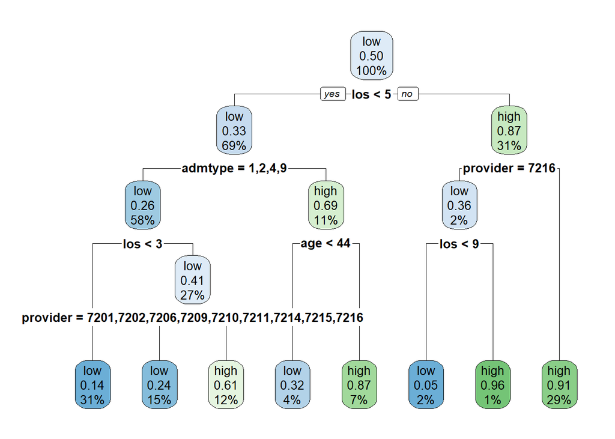

   ```r
   tree_fit <- rpart(target ~ ., data = train_df, method = "class")
   rpart.plot(tree_fit)
   ```

   ```r
   tree_importance <- data.frame(
     variable = names(tree_fit$variable.importance),
     importance = tree_fit$variable.importance
   ) %>%
     arrange(desc(importance))

   tree_importance
   ```

   ```
   ##          variable  importance
   ## los           los 1982.122104
   ## admtype   admtype  515.740440
   ## provider provider  512.605478
   ## age           age  262.622828
   ## campus     campus  144.022436
   ## raceethn raceethn   27.249337
   ## sex           sex    5.747264
   ## mod           mod    3.631862
   ```

3. Using caret for this question. Set `Training Control` to be: Use Cross-Validation of 5 folds across all models. Train & tune at least 2 different models (i.e. two different values for `method=` in the train function of caret). Plot the hyper-parameter tuning plots for each model.

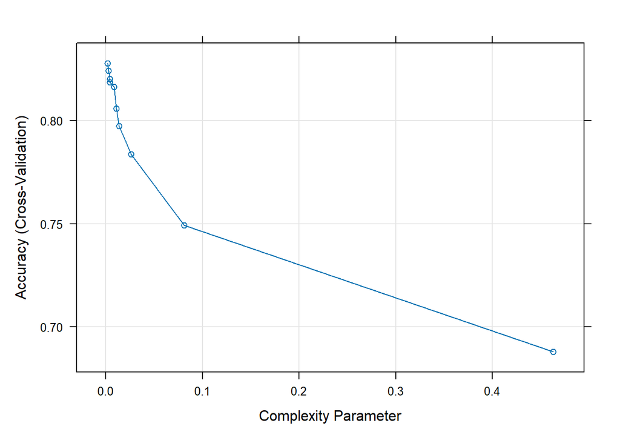

   ```r
   ctrl <- trainControl(method = "cv", number = 5)

   set.seed(123)
   model_rpart <- train(
     target ~ ., data = train_df,
     method = "rpart",
     trControl = ctrl,
     tuneLength = 10
   )

   set.seed(123)
   model_knn <- train(
     target ~ ., data = train_df,
     method = "knn",
     trControl = ctrl,
     tuneLength = 15
   )

   plot(model_rpart)
   ```

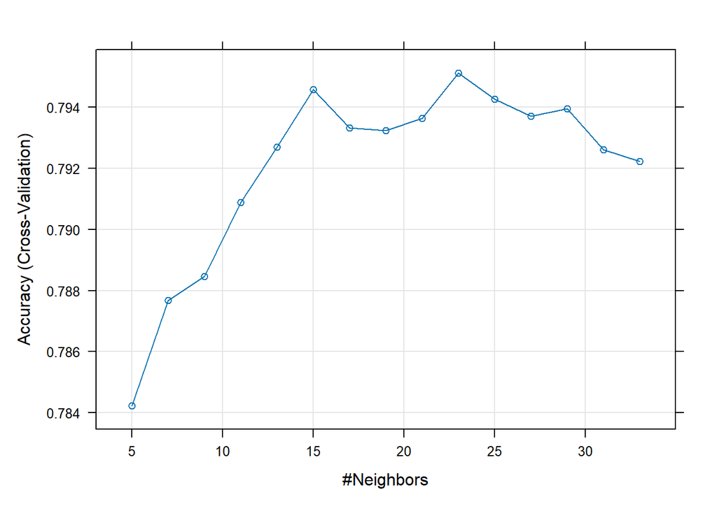

   ```r
   plot(model_knn)
   ```

4. Plot the comparison of the models in 3.

   ```r
   res <- resamples(list(DecisionTree = model_rpart, KNN = model_knn))
   summary(res)
   ```

   ```
   ##
   ## Call:
   ## summary.resamples(object = res)
   ##
   ## Models: DecisionTree, KNN
   ## Number of resamples: 5
   ##
   ## Accuracy
   ##                   Min.   1st Qu.    Median      Mean   3rd Qu.      Max. NA's
   ## DecisionTree 0.8177900 0.8227451 0.8302626 0.8278197 0.8330067 0.8352941    0
   ## KNN          0.7829154 0.7854902 0.7989024 0.7951241 0.8032144 0.8050980    0
   ##
   ## Kappa
   ##                   Min.   1st Qu.    Median      Mean   3rd Qu.      Max. NA's
   ## DecisionTree 0.6355799 0.6454902 0.6605343 0.6556395 0.6660047 0.6705882    0
   ## KNN          0.5658307 0.5709804 0.5978296 0.5902502 0.6064140 0.6101961    0
   ```

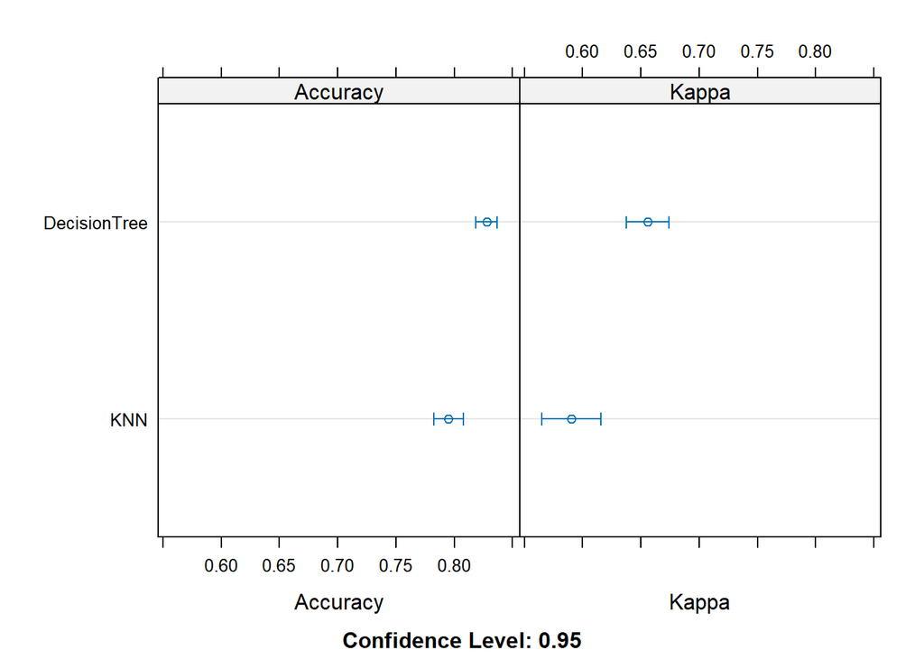

   ```r
   dotplot(res)
   ```

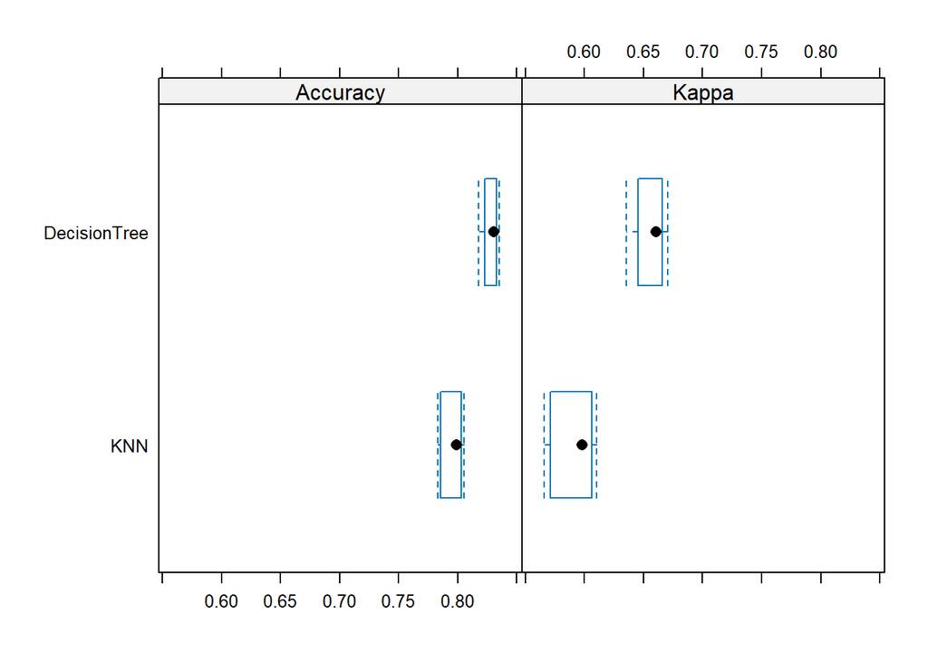

   ```r
   bwplot(res)
   ```

5. What is your final selection for the model? Test the accuracy of your final model on the test data.

   ```r
   best_model <- if (
     max(model_rpart$results$Accuracy) >= max(model_knn$results$Accuracy)
   ) model_rpart else model_knn

   pred <- predict(best_model, test_df)
   confusionMatrix(pred, test_df$target)
   ```

   ```
   ## Confusion Matrix and Statistics
   ##
   ##           Reference
   ## Prediction   low  high
   ##       low  48770 11814
   ##       high  8615 45574
   ##
   ##                Accuracy : 0.822
   ##                  95% CI : (0.8198, 0.8242)
   ##     No Information Rate : 0.5
   ##     P-Value [Acc > NIR] : < 2.2e-16
   ##
   ##                   Kappa : 0.644
   ##
   ##  Mcnemar's Test P-Value : < 2.2e-16
   ##
   ##             Sensitivity : 0.8499
   ##             Specificity : 0.7941
   ##          Pos Pred Value : 0.8050
   ##          Neg Pred Value : 0.8410
   ##              Prevalence : 0.5000
   ##          Detection Rate : 0.4249
   ##    Detection Prevalence : 0.5279
   ##       Balanced Accuracy : 0.8220
   ##
   ##        'Positive' Class : low
   ##
   ```

6. Create another `target` variable (binary), decide the input variables and redo 1 to 5.

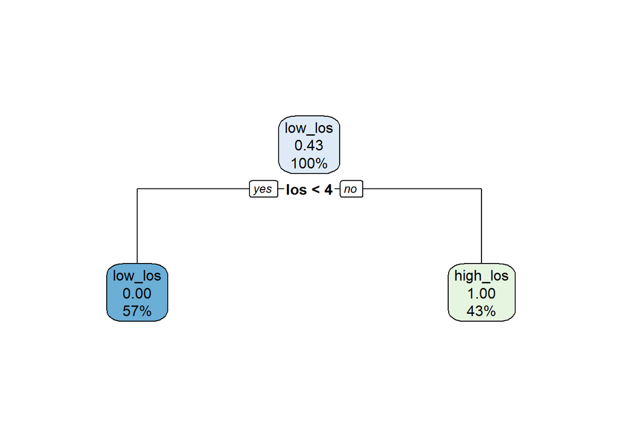

   ```r
   model_df2 <- df18 %>%
     select(age, sex, raceethn, provider, moa, mod, admtype, campus, los) %>%
     filter(raceethn != "", admtype != "") %>%
     drop_na()

   med_los <- median(as.numeric(model_df2$los))

   model_df2 <- model_df2 %>%
     mutate(
       target2 = ifelse(as.numeric(los) > med_los, "high_los", "low_los"),
       target2 = factor(target2, levels = c("low_los","high_los")),
       age = as.numeric(age),
       los = as.numeric(los),
       moa = factor(moa),
       mod = factor(mod),
       sex = factor(sex),
       raceethn = factor(raceethn),
       provider = factor(provider),
       admtype = factor(admtype),
       campus = factor(campus)
     )

   set.seed(456)
   idx2 <- createDataPartition(model_df2$target2, p = 0.10, list = FALSE)
   train2 <- model_df2[idx2, ]
   test2  <- model_df2[-idx2, ]

   tree2 <- rpart(target2 ~ ., data = train2, method = "class")
   rpart.plot(tree2)
   ```

   ```r
   ctrl2 <- trainControl(method = "cv", number = 5)

   set.seed(456)
   model2_rpart <- train(target2 ~ ., data = train2, method = "rpart", trControl = ctrl2, tuneLength = 10)

   set.seed(456)
   model2_knn <- train(target2 ~ ., data = train2, method = "knn", trControl = ctrl2, tuneLength = 15)

   res2 <- resamples(list(DecisionTree = model2_rpart, KNN = model2_knn))
   summary(res2)
   ```

   ```
   ##
   ## Call:
   ## summary.resamples(object = res2)
   ##
   ## Models: DecisionTree, KNN
   ## Number of resamples: 5
   ##
   ## Accuracy
   ##                   Min.  1st Qu.    Median      Mean   3rd Qu.      Max. NA's
   ## DecisionTree 1.0000000 1.000000 1.0000000 1.0000000 1.0000000 1.0000000    0
   ## KNN          0.9705882 0.972549 0.9741278 0.9744369 0.9753038 0.9796158    0
   ##
   ## Kappa
   ##                   Min.   1st Qu.    Median      Mean   3rd Qu.      Max. NA's
   ## DecisionTree 1.0000000 1.0000000 1.0000000 1.0000000 1.0000000 1.0000000    0
   ## KNN          0.9393485 0.9434255 0.9466983 0.9473424 0.9491653 0.9580744    0
   ```

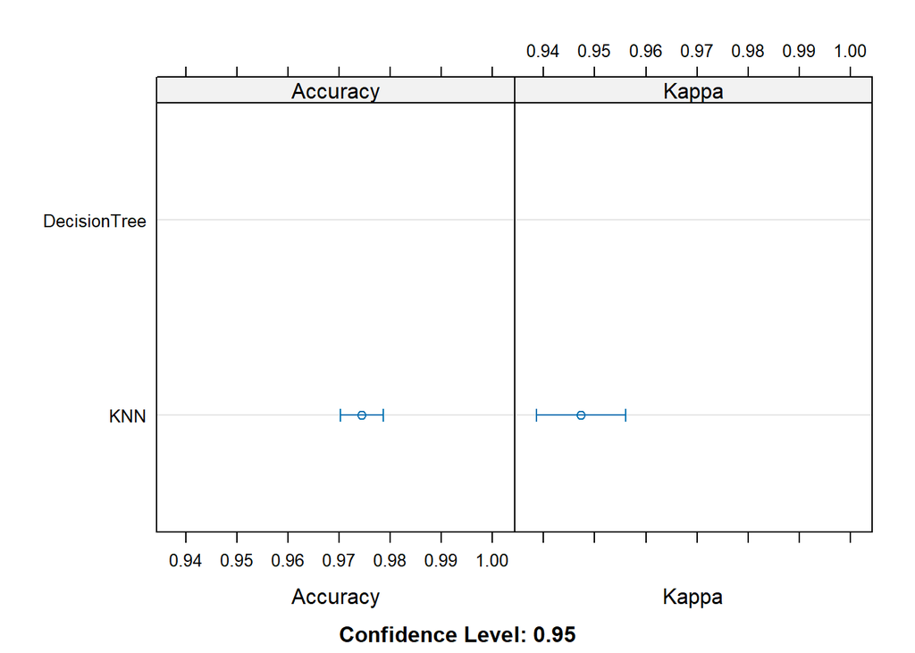

   ```r
   dotplot(res2)
   ```

   ```r
   best2 <- if (
     max(model2_rpart$results$Accuracy) >= max(model2_knn$results$Accuracy)
   ) model2_rpart else model2_knn

   pred2 <- predict(best2, test2)
   confusionMatrix(pred2, test2$target2)
   ```

7. Write a paragraph to summarize the section and give your comments on the results.

Both the KNN and decision tree models were used to predict the charge level base don demographics and other variables. Length of stay, provider, admission type, and patient age showed to be the variables with high importance. The decision tree was the final model I used due to it’s higher accuracy. The final accuracy was 0.822. The p value was 2.2e-16, which is strong; it’s well below .05.